# Regression Model for Superconductor Critical Temperature Using XGBoost Take 1

### September 17, 2020

Template Credit: Adapted from a template made available by Dr. Jason Brownlee of Machine Learning Mastery. [https://machinelearningmastery.com/]

SUMMARY: The purpose of this project is to construct a predictive model using various machine learning algorithms and to document the end-to-end steps using a template. The Superconductor Critical Temperature dataset is a regression situation where we are trying to predict the value of a continuous variable.

INTRODUCTION: The research team wishes to create a statistical model for predicting the superconducting critical temperature based on the features extracted from the superconductor’s chemical formula. The model seeks to examine the features that can contribute the most to the model’s predictive accuracy.

From previous iterations, we constructed and tuned several classic machine learning models using the Scikit-Learn library. We also observed the best results that we could obtain from the models.

In this Take1 iteration, we will construct and tune an XGBoost model. Furthermore, we will apply the XGBoost model to a test dataset and observe the best result that we can obtain from the model.

ANALYSIS: From previous iterations, the Extra Trees model turned in the best overall result and achieved an RMSE metric of 9.56. By using the optimized parameters, the Extra Trees algorithm processed the test dataset with an RMSE of 9.32.

In this Take1 iteration, the baseline performance of the XGBoost algorithm achieved an RMSE benchmark of 12.88. After a series of tuning trials, the XGBoost model processed the validation dataset with an RMSE score of 9.88. When we applied the XGBoost model to the previously unseen test dataset, we obtained an RMSE score of 9.06.

CONCLUSION: In this iteration, the XGBoost model appeared to be a suitable algorithm for modeling this dataset. We should consider using the algorithm for further modeling.

Dataset Used: Superconductivity Data Set

Dataset ML Model: Regression with numerical attributes

Dataset Reference: https://archive.ics.uci.edu/ml/datasets/Superconductivty+Data

One potential source of performance benchmarks: https://doi.org/10.1016/j.commatsci.2018.07.052

Any predictive modeling machine learning project generally can be broken down into about six major tasks:

1. Prepare Environment
2. Summarize and Visualize Data
3. Pre-process Data
4. Train and Evaluate Models
5. Fine-tune and Improve Models
6. Finalize Model and Present Analysis

## Task 1 - Prepare Environment

```python
# Install the necessary packages for Colab
!pip install python-dotenv PyMySQL
```

```
     |████████████████████████████████| 51kB 4.9MB/s
```

```python
# Retrieve the GPU information from Colab
gpu_info = !nvidia-smi
gpu_info = '\n'.join(gpu_info)
if gpu_info.find('failed') >= 0:
    print('Select the Runtime → "Change runtime type" menu to enable a GPU accelerator, ')
    print('and then re-execute this cell.')
else:
    print(gpu_info)
```

```
Wed Sep  9 19:01:22 2020
+-----------------------------------------------------------------------------+
| NVIDIA-SMI 450.66       Driver Version: 418.67       CUDA Version: 10.1     |
|-------------------------------+----------------------+----------------------+
| GPU  Name        Persistence-M| Bus-Id        Disp.A | Volatile Uncorr. ECC |
| Fan  Temp  Perf  Pwr:Usage/Cap|         Memory-Usage | GPU-Util  Compute M. |
|                               |                      |               MIG M. |
|===============================+======================+======================|
|   0  Tesla V100-SXM2...  Off  | 00000000:00:04.0 Off |                    0 |
| N/A   45C    P0    24W / 300W |      0MiB / 16130MiB |      0%      Default |
|                               |                      |                 ERR! |
+-------------------------------+----------------------+----------------------+

+-----------------------------------------------------------------------------+
| Processes:                                                                  |
|  GPU   GI   CI        PID   Type   Process name                  GPU Memory |
|        ID   ID                                                   Usage      |
|=============================================================================|
|  No running processes found                                                 |
+-----------------------------------------------------------------------------+
```

```python
# Retrieve the memory configuration from Colab
from psutil import virtual_memory
ram_gb = virtual_memory().total / 1e9
print('Your runtime has {:.1f} gigabytes of available RAM\n'.format(ram_gb))

if ram_gb < 20:
    print('To enable a high-RAM runtime, select the Runtime → "Change runtime type"')
    print('menu, and then select High-RAM in the Runtime shape dropdown. Then, ')
    print('re-execute this cell.')
else:
    print('You are using a high-RAM runtime!')
```

```
Your runtime has 13.7 gigabytes of available RAM

To enable a high-RAM runtime, select the Runtime → "Change runtime type"
menu, and then select High-RAM in the Runtime shape dropdown. Then,
re-execute this cell.
```

```python
# Retrieve the CPU information
ncpu = !nproc
print("The number of available CPUs is:", ncpu[0])
```

```
The number of available CPUs is: 2
```

### 1.a) Load libraries and modules

```python
# Set the random seed number for reproducible results
seedNum = 888
```

```python
import numpy as np
import pandas as pd
import matplotlib.pyplot as plt
import os
import sys
import math
import boto3
from datetime import datetime
from dotenv import load_dotenv
from sklearn import preprocessing
from sklearn.model_selection import train_test_split
from sklearn.model_selection import KFold
from sklearn.model_selection import StratifiedKFold
from sklearn.model_selection import cross_val_score
from sklearn.model_selection import GridSearchCV
from sklearn.metrics import mean_squared_error
from sklearn.metrics import r2_score
# from sklearn.pipeline import Pipeline
# from sklearn.feature_selection import RFE
# from imblearn.pipeline import Pipeline
# from imblearn.over_sampling import SMOTE
# from imblearn.under_sampling import RandomUnderSampler
from xgboost import XGBRegressor
```

### 1.b) Set up the controlling parameters and functions

```python
# Begin the timer for the script processing
startTimeScript = datetime.now()

# Set up the number of CPU cores available for multi-thread processing
n_jobs = 1

# Set up the flag to stop sending progress emails (setting to True will send status emails!)
notifyStatus = False

# Set up the parent directory location for loading the dotenv files
useColab = False
if useColab:
    # Mount Google Drive locally for storing files
    from google.colab import drive
    drive.mount('/content/gdrive')
    gdrivePrefix = '/content/gdrive/My Drive/Colab_Downloads/'
    env_path = '/content/gdrive/My Drive/Colab Notebooks/'
    dotenv_path = env_path + "python_script.env"
    load_dotenv(dotenv_path=dotenv_path)

# Set up the dotenv file for retrieving environment variables
useLocalPC = False
if useLocalPC:
    env_path = "/Users/david/PycharmProjects/"
    dotenv_path = env_path + "python_script.env"
    load_dotenv(dotenv_path=dotenv_path)

# Configure the plotting style
plt.style.use('seaborn')

# Set Pandas options
pd.set_option("display.max_rows", 500)
pd.set_option("display.width", 140)

# Set the percentage sizes for splitting the dataset
test_set_size = 0.2
val_set_size = 0.25

# Set the number of folds for cross validation
n_folds = 5

# Set various default modeling parameters
scoring = 'neg_mean_squared_error'
```

```python
# Set up the email notification function
def status_notify(msg_text):
    access_key = os.environ.get('SNS_ACCESS_KEY')
    secret_key = os.environ.get('SNS_SECRET_KEY')
    aws_region = os.environ.get('SNS_AWS_REGION')
    topic_arn = os.environ.get('SNS_TOPIC_ARN')
    if (access_key is None) or (secret_key is None) or (aws_region is None):
        sys.exit("Incomplete notification setup info. Script Processing Aborted!!!")
    sns = boto3.client('sns', aws_access_key_id=access_key, aws_secret_access_key=secret_key, region_name=aws_region)
    response = sns.publish(TopicArn=topic_arn, Message=msg_text)
    if response['ResponseMetadata']['HTTPStatusCode'] != 200 :
        print('Status notification not OK with HTTP status code:', response['ResponseMetadata']['HTTPStatusCode'])
```

```python
if notifyStatus: status_notify("Task 1 - Prepare Environment has begun! " + datetime.now().strftime('%a %B %d, %Y %I:%M:%S %p'))
```

### 1.c) Load dataset

```python
dataset_path = 'https://dainesanalytics.com/datasets/ucirvine-superconductor-critical-temperature/train.csv'
Xy_original = pd.read_csv(dataset_path)

# Take a peek at the dataframe after import
print(Xy_original.head())
```

```
   number_of_elements  mean_atomic_mass  ...  wtd_std_Valence  critical_temp
0                   4         88.944468  ...         0.437059           29.0
1                   5         92.729214  ...         0.468606           26.0
2                   4         88.944468  ...         0.444697           19.0
3                   4         88.944468  ...         0.440952           22.0
4                   4         88.944468  ...         0.428809           23.0

[5 rows x 82 columns]
```

```python
Xy_original.info(verbose=True)
```

```
<class 'pandas.core.frame.DataFrame'>
RangeIndex: 21263 entries, 0 to 21262
Data columns (total 82 columns):
 #   Column                           Non-Null Count  Dtype
---  ------                           --------------  -----
 0   number_of_elements               21263 non-null  int64
 1   mean_atomic_mass                 21263 non-null  float64
 2   wtd_mean_atomic_mass             21263 non-null  float64
 3   gmean_atomic_mass                21263 non-null  float64
 4   wtd_gmean_atomic_mass            21263 non-null  float64
 5   entropy_atomic_mass              21263 non-null  float64
 6   wtd_entropy_atomic_mass          21263 non-null  float64
 7   range_atomic_mass                21263 non-null  float64
 8   wtd_range_atomic_mass            21263 non-null  float64
 9   std_atomic_mass                  21263 non-null  float64
```

[output cut: 74 more lines]

```python
print(Xy_original.describe())
```

```
       number_of_elements  mean_atomic_mass  ...  wtd_std_Valence  critical_temp
count        21263.000000      21263.000000  ...     21263.000000   21263.000000
mean             4.115224         87.557631  ...         0.673987      34.421219
std              1.439295         29.676497  ...         0.455580      34.254362
min              1.000000          6.941000  ...         0.000000       0.000210
25%              3.000000         72.458076  ...         0.306892       5.365000
50%              4.000000         84.922750  ...         0.500000      20.000000
75%              5.000000        100.404410  ...         1.020436      63.000000
max              9.000000        208.980400  ...         3.000000     185.000000

[8 rows x 82 columns]
```

```python
Xy_original.isnull().sum()
```

```
number_of_elements                 0
mean_atomic_mass                   0
wtd_mean_atomic_mass               0
gmean_atomic_mass                  0
wtd_gmean_atomic_mass              0
entropy_atomic_mass                0
wtd_entropy_atomic_mass            0
range_atomic_mass                  0
wtd_range_atomic_mass              0
std_atomic_mass                    0
wtd_std_atomic_mass                0
mean_fie                           0
wtd_mean_fie                       0
gmean_fie                          0
wtd_gmean_fie                      0
entropy_fie                        0
wtd_entropy_fie                    0
range_fie                          0
wtd_range_fie                      0
std_fie                            0
wtd_std_fie                        0
mean_atomic_radius                 0
wtd_mean_atomic_radius             0
gmean_atomic_radius                0
wtd_gmean_atomic_radius            0
entropy_atomic_radius              0
wtd_entropy_atomic_radius          0
range_atomic_radius                0
wtd_range_atomic_radius            0
std_atomic_radius                  0
wtd_std_atomic_radius              0
mean_Density                       0
wtd_mean_Density                   0
gmean_Density                      0
wtd_gmean_Density                  0
entropy_Density                    0
wtd_entropy_Density                0
range_Density                      0
wtd_range_Density                  0
std_Density                        0
```

[output cut: 28 more lines]

```
wtd_range_ThermalConductivity      0
std_ThermalConductivity            0
wtd_std_ThermalConductivity        0
mean_Valence                       0
wtd_mean_Valence                   0
gmean_Valence                      0
wtd_gmean_Valence                  0
entropy_Valence                    0
wtd_entropy_Valence                0
range_Valence                      0
wtd_range_Valence                  0
std_Valence                        0
wtd_std_Valence                    0
critical_temp                      0
dtype: int64
```

```python
print('Total number of NaN in the dataframe: ', Xy_original.isnull().sum().sum())
```

```
Total number of NaN in the dataframe:  0
```

### 1.d) Data Cleaning

```python
# Standardize the class column to the name of targetVar if required
Xy_original = Xy_original.rename(columns={'critical_temp': 'targetVar'})

# Dropping features
Xy_original.drop(columns=['number_of_elements'], inplace=True)

# Convert columns from one data type to another
Xy_original['range_atomic_radius'] = Xy_original['range_atomic_radius'].astype('float')
Xy_original['range_Valence'] = Xy_original['range_Valence'].astype('float')

# Take a peek at the dataframe after cleaning
print(Xy_original.head())
```

```
   mean_atomic_mass  wtd_mean_atomic_mass  ...  wtd_std_Valence  targetVar
0         88.944468             57.862692  ...         0.437059       29.0
1         92.729214             58.518416  ...         0.468606       26.0
2         88.944468             57.885242  ...         0.444697       19.0
3         88.944468             57.873967  ...         0.440952       22.0
4         88.944468             57.840143  ...         0.428809       23.0

[5 rows x 81 columns]
```

```python
Xy_original.info(verbose=True)
```

```
<class 'pandas.core.frame.DataFrame'>
RangeIndex: 21263 entries, 0 to 21262
Data columns (total 81 columns):
 #   Column                           Non-Null Count  Dtype
---  ------                           --------------  -----
 0   mean_atomic_mass                 21263 non-null  float64
 1   wtd_mean_atomic_mass             21263 non-null  float64
 2   gmean_atomic_mass                21263 non-null  float64
 3   wtd_gmean_atomic_mass            21263 non-null  float64
 4   entropy_atomic_mass              21263 non-null  float64
 5   wtd_entropy_atomic_mass          21263 non-null  float64
 6   range_atomic_mass                21263 non-null  float64
 7   wtd_range_atomic_mass            21263 non-null  float64
 8   std_atomic_mass                  21263 non-null  float64
 9   wtd_std_atomic_mass              21263 non-null  float64
```

[output cut: 73 more lines]

```python
print(Xy_original.describe())
```

```
       mean_atomic_mass  wtd_mean_atomic_mass  ...  wtd_std_Valence     targetVar
count      21263.000000          21263.000000  ...     21263.000000  21263.000000
mean          87.557631             72.988310  ...         0.673987     34.421219
std           29.676497             33.490406  ...         0.455580     34.254362
min            6.941000              6.423452  ...         0.000000      0.000210
25%           72.458076             52.143839  ...         0.306892      5.365000
50%           84.922750             60.696571  ...         0.500000     20.000000
75%          100.404410             86.103540  ...         1.020436     63.000000
max          208.980400            208.980400  ...         3.000000    185.000000

[8 rows x 81 columns]
```

```python
Xy_original.isnull().sum()
```

```
mean_atomic_mass                   0
wtd_mean_atomic_mass               0
gmean_atomic_mass                  0
wtd_gmean_atomic_mass              0
entropy_atomic_mass                0
wtd_entropy_atomic_mass            0
range_atomic_mass                  0
wtd_range_atomic_mass              0
std_atomic_mass                    0
wtd_std_atomic_mass                0
mean_fie                           0
wtd_mean_fie                       0
gmean_fie                          0
wtd_gmean_fie                      0
entropy_fie                        0
wtd_entropy_fie                    0
range_fie                          0
wtd_range_fie                      0
std_fie                            0
wtd_std_fie                        0
mean_atomic_radius                 0
wtd_mean_atomic_radius             0
gmean_atomic_radius                0
wtd_gmean_atomic_radius            0
entropy_atomic_radius              0
wtd_entropy_atomic_radius          0
range_atomic_radius                0
wtd_range_atomic_radius            0
std_atomic_radius                  0
wtd_std_atomic_radius              0
mean_Density                       0
wtd_mean_Density                   0
gmean_Density                      0
wtd_gmean_Density                  0
entropy_Density                    0
wtd_entropy_Density                0
range_Density                      0
wtd_range_Density                  0
std_Density                        0
wtd_std_Density                    0
```

[output cut: 27 more lines]

```
wtd_range_ThermalConductivity      0
std_ThermalConductivity            0
wtd_std_ThermalConductivity        0
mean_Valence                       0
wtd_mean_Valence                   0
gmean_Valence                      0
wtd_gmean_Valence                  0
entropy_Valence                    0
wtd_entropy_Valence                0
range_Valence                      0
wtd_range_Valence                  0
std_Valence                        0
wtd_std_Valence                    0
targetVar                          0
dtype: int64
```

```python
print('Total number of NaN in the dataframe: ', Xy_original.isnull().sum().sum())
```

```
Total number of NaN in the dataframe:  0
```

### 1.e) Splitting Data into Attribute-only and Target-only Sets

```python
# Use variable totCol to hold the number of columns in the dataframe
totCol = len(Xy_original.columns)

# Set up variable totAttr for the total number of attribute columns
totAttr = totCol-1

# targetCol variable indicates the column location of the target/class variable
# If the first column, set targetCol to 1. If the last column, set targetCol to totCol
# If (targetCol <> 1) and (targetCol <> totCol), be aware when slicing up the dataframes for visualization
targetCol = totCol
```

```python
# We create attribute-only and target-only datasets (X_original and y_original)
# for various visualization and cleaning/transformation operations

if targetCol == totCol:
    X_original = Xy_original.iloc[:,0:totAttr]
    y_original = Xy_original.iloc[:,totAttr]
else:
    X_original = Xy_original.iloc[:,1:totCol]
    y_original = Xy_original.iloc[:,0]

print("Xy_original.shape: {} X_original.shape: {} y_original.shape: {}".format(Xy_original.shape, X_original.shape, y_original.shape))
```

```
Xy_original.shape: (21263, 81) X_original.shape: (21263, 80) y_original.shape: (21263,)
```

### 1.f) Set up the parameters for data visualization

```python
# Set up the number of row and columns for visualization display. dispRow * dispCol should be >= totAttr
dispCol = 4
if totAttr % dispCol == 0 :
    dispRow = totAttr // dispCol
else :
    dispRow = (totAttr // dispCol) + 1

# Set figure width to display the data visualization plots
fig_size = plt.rcParams["figure.figsize"]
fig_size[0] = dispCol*4
fig_size[1] = dispRow*4
plt.rcParams["figure.figsize"] = fig_size
```

```python
if notifyStatus: status_notify("Task 1 - Prepare Environment completed! "+datetime.now().strftime('%a %B %d, %Y %I:%M:%S %p'))
```

## Task 2 - Summarize and Visualize Data

```python
if notifyStatus: status_notify("Task 2 - Summarize and Visualize Data has begun! "+datetime.now().strftime('%a %B %d, %Y %I:%M:%S %p'))
```

### 2.a) Descriptive Statistics

#### 2.a.i) Peek at the attribute columns

```python
print(X_original.head())
```

```
   mean_atomic_mass  wtd_mean_atomic_mass  ...  std_Valence  wtd_std_Valence
0         88.944468             57.862692  ...     0.433013         0.437059
1         92.729214             58.518416  ...     0.632456         0.468606
2         88.944468             57.885242  ...     0.433013         0.444697
3         88.944468             57.873967  ...     0.433013         0.440952
4         88.944468             57.840143  ...     0.433013         0.428809

[5 rows x 80 columns]
```

#### 2.a.ii) Dimensions and attribute types

```python
X_original.info(verbose=True)
```

```
<class 'pandas.core.frame.DataFrame'>
RangeIndex: 21263 entries, 0 to 21262
Data columns (total 80 columns):
 #   Column                           Non-Null Count  Dtype
---  ------                           --------------  -----
 0   mean_atomic_mass                 21263 non-null  float64
 1   wtd_mean_atomic_mass             21263 non-null  float64
 2   gmean_atomic_mass                21263 non-null  float64
 3   wtd_gmean_atomic_mass            21263 non-null  float64
 4   entropy_atomic_mass              21263 non-null  float64
 5   wtd_entropy_atomic_mass          21263 non-null  float64
 6   range_atomic_mass                21263 non-null  float64
 7   wtd_range_atomic_mass            21263 non-null  float64
 8   std_atomic_mass                  21263 non-null  float64
 9   wtd_std_atomic_mass              21263 non-null  float64
```

[output cut: 72 more lines]

#### 2.a.iii) Statistical summary of the attributes

```python
print(X_original.describe())
```

```
       mean_atomic_mass  wtd_mean_atomic_mass  ...   std_Valence  wtd_std_Valence
count      21263.000000          21263.000000  ...  21263.000000     21263.000000
mean          87.557631             72.988310  ...      0.839342         0.673987
std           29.676497             33.490406  ...      0.484676         0.455580
min            6.941000              6.423452  ...      0.000000         0.000000
25%           72.458076             52.143839  ...      0.451754         0.306892
50%           84.922750             60.696571  ...      0.800000         0.500000
75%          100.404410             86.103540  ...      1.200000         1.020436
max          208.980400            208.980400  ...      3.000000         3.000000

[8 rows x 80 columns]
```

### 2.b) Data Visualization

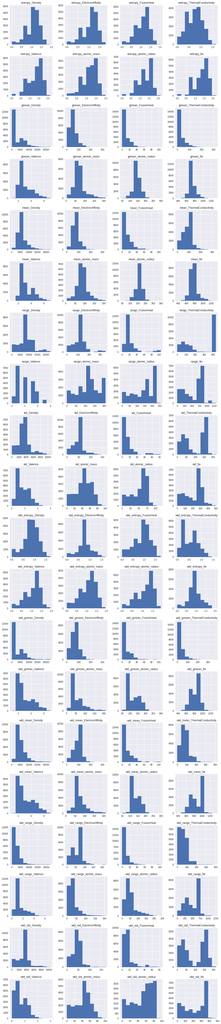

```python
# Histograms for each attribute
X_original.hist(layout=(dispRow,dispCol))
plt.show()
```

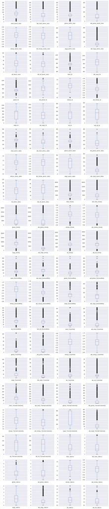

```python
# Box and Whisker plot for each attribute
X_original.plot(kind='box', subplots=True, layout=(dispRow,dispCol))
plt.show()
```

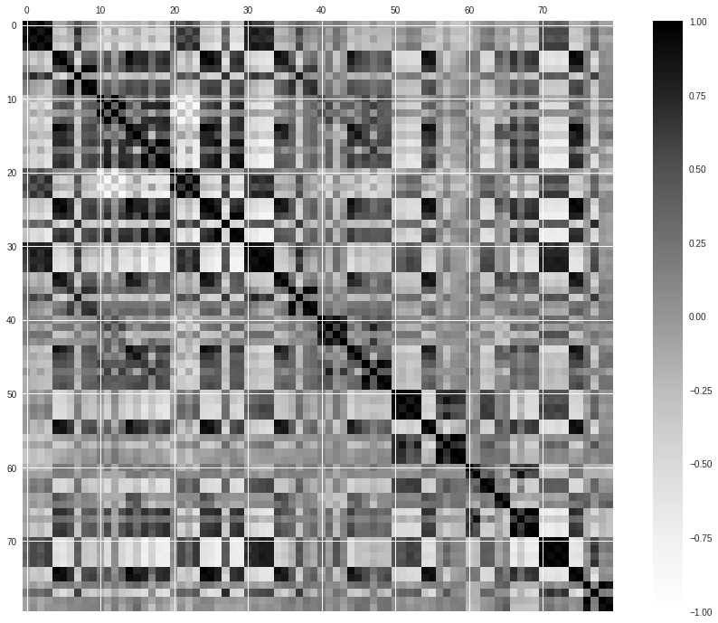

```python
# Correlation matrix
fig = plt.figure(figsize=(16,12))
ax = fig.add_subplot(111)
correlations = X_original.corr(method='pearson')
cax = ax.matshow(correlations, vmin=-1, vmax=1)
fig.colorbar(cax)
plt.show()
```

```python
if notifyStatus: status_notify("Task 2 - Summarize and Visualize Data completed! "+datetime.now().strftime('%a %B %d, %Y %I:%M:%S %p'))
```

## Task 3 - Pre-process Data

```python
if notifyStatus: status_notify("Task 3 - Pre-process Data has begun! "+datetime.now().strftime('%a %B %d, %Y %I:%M:%S %p'))
```

### 3.a) Splitting Data into Training and Test Sets

```python
# Not applicable for this iteration of the project
# Perform one-hot-encoding on the categorical attributes
# X_original = pd.get_dummies(X_original)
# print(X_original.info())
```

```python
# Split the data further into training, validation, and test datasets
X_train_val, X_test_df, y_train_val, y_test_df = train_test_split(X_original, y_original, test_size=test_set_size, random_state=seedNum)
X_train_df, X_validation_df, y_train_df, y_validation_df = train_test_split(X_train_val, y_train_val, test_size=val_set_size, random_state=seedNum)
print("X_train_df.shape: {} y_train_df.shape: {}".format(X_train_df.shape, y_train_df.shape))
print("X_validation_df.shape: {} y_validation_df.shape: {}".format(X_validation_df.shape, y_validation_df.shape))
print("X_test_df.shape: {} y_test_df.shape: {}".format(X_test_df.shape, y_test_df.shape))
```

```
X_train_df.shape: (12757, 80) y_train_df.shape: (12757,)
X_validation_df.shape: (4253, 80) y_validation_df.shape: (4253,)
X_test_df.shape: (4253, 80) y_test_df.shape: (4253,)
```

### 3.b) Feature Scaling and Data Pre-Processing

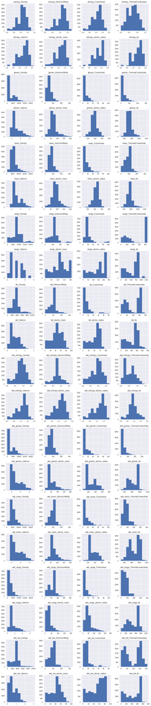

```python
# Histograms for each attribute before pre-processing
columns_to_scale = X_train_df.columns[X_train_df.dtypes == 'float'].tolist()
X_train_df[columns_to_scale].hist(layout=(dispRow,dispCol))
plt.show()
```

```python
# Apply feature scaling and transformation
print('Columns to scale are:', columns_to_scale)
scaler = preprocessing.MinMaxScaler()
X_train_df[columns_to_scale] = scaler.fit_transform(X_train_df[columns_to_scale])
print(X_train_df.head())
```

```
Columns to scale are: ['mean_atomic_mass', 'wtd_mean_atomic_mass', 'gmean_atomic_mass', 'wtd_gmean_atomic_mass', 'entropy_atomic_mass', 'wtd_entropy_atomic_mass', 'range_atomic_mass', 'wtd_range_atomic_mass', 'std_atomic_mass', 'wtd_std_atomic_mass', 'mean_fie', 'wtd_mean_fie', 'gmean_fie', 'wtd_gme…
       mean_atomic_mass  wtd_mean_atomic_mass  ...  std_Valence  wtd_std_Valence
14555          0.642707              0.430204  ...     0.157135         0.151254
11161          0.375002              0.184790  ...     0.333333         0.234293
12506          0.415720              0.420759  ...     0.000000         0.000000
20893          0.563514              0.370088  ...     0.415740         0.351540
13709          0.284733              0.263731  ...     0.628539         0.332592

[5 rows x 80 columns]
```

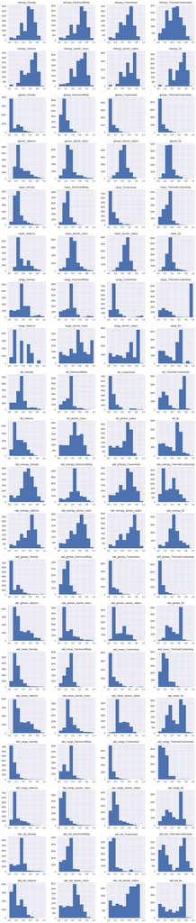

```python
# Histograms for each attribute after pre-processing
X_train_df[columns_to_scale].hist(layout=(dispRow,dispCol))
plt.show()
```

```python
# Apply feature scaling and transformation to the validation dataset
scaled_features = scaler.transform(X_validation_df[columns_to_scale])
X_validation_df.loc[:,tuple(columns_to_scale)] = scaled_features
print(X_validation_df.head())
```

```
       mean_atomic_mass  wtd_mean_atomic_mass  ...  std_Valence  wtd_std_Valence
11987          0.912112              0.914789  ...     0.000000         0.000000
1466           0.525571              0.293103  ...     0.384900         0.324007
17982          0.238809              0.212358  ...     0.133333         0.128565
17434          0.341940              0.203098  ...     0.166667         0.124226
449            0.420052              0.246924  ...     0.144338         0.089297

[5 rows x 80 columns]
```

### 3.c) Training Data Balancing

```python
# Not applicable for this iteration of the project
```

### 3.d) Feature Selection

```python
# Not applicable for this iteration of the project
```

### 3.e) Display the Final Datasets for Model-Building

```python
# Finalize the training and validation datasets for the modeling activities
X_train = X_train_df.to_numpy()
y_train = y_train_df.ravel()
X_validation = X_validation_df.to_numpy()
y_validation = y_validation_df.ravel()
print("X_train.shape: {} y_train.shape: {}".format(X_train.shape, y_train.shape))
print("X_validation.shape: {} y_validation.shape: {}".format(X_validation.shape, y_validation.shape))
```

```
X_train.shape: (12757, 80) y_train.shape: (12757,)
X_validation.shape: (4253, 80) y_validation.shape: (4253,)
```

```python
if notifyStatus: status_notify("Task 3 - Pre-process Data completed! "+datetime.now().strftime('%a %B %d, %Y %I:%M:%S %p'))
```

## Task 4 - Train and Evaluate Models

```python
if notifyStatus: status_notify("Task 4 - Train and Evaluate Models has begun! "+datetime.now().strftime('%a %B %d, %Y %I:%M:%S %p'))
```

### 4.a) Set test options and evaluation metric

```python
# Set up Algorithms Spot-Checking Array
startTimeTraining = datetime.now()
startTimeModule = datetime.now()
train_models = []
train_results = []
train_model_names = []
train_metrics = []
train_models.append(('XGB', XGBRegressor(random_state=seedNum, n_jobs=n_jobs, objective='reg:squarederror', tree_method='gpu_hist')))
```

```python
# Generate model in turn
for name, model in train_models:
	if notifyStatus: status_notify("Algorithm "+name+" modeling has begun! "+datetime.now().strftime('%a %B %d, %Y %I:%M:%S %p'))
	startTimeModule = datetime.now()
	kfold = KFold(n_splits=n_folds, shuffle=True, random_state=seedNum)
	cv_results = cross_val_score(model, X_train, y_train, cv=kfold, scoring=scoring, n_jobs=n_jobs, verbose=1)
	train_results.append(cv_results)
	train_model_names.append(name)
	train_metrics.append(cv_results.mean())
	print("%s: %f (%f)" % (name, cv_results.mean(), cv_results.std()))
	print(model)
	print ('Model training time:', (datetime.now() - startTimeModule), '\n')
	if notifyStatus: status_notify("Algorithm "+name+" modeling completed! "+datetime.now().strftime('%a %B %d, %Y %I:%M:%S %p'))
print ('Average metrics ('+scoring+') from all models:',np.mean(train_metrics))
print ('Average RMSE for all models is:', math.sqrt((np.mean(train_metrics)*-1)))
print ('Total training time for all models:',(datetime.now() - startTimeTraining))
```

```
[Parallel(n_jobs=1)]: Using backend SequentialBackend with 1 concurrent workers.
```

```
XGB: -166.001168 (11.544692)
XGBRegressor(base_score=0.5, booster='gbtree', colsample_bylevel=1,
             colsample_bynode=1, colsample_bytree=1, gamma=0,
             importance_type='gain', learning_rate=0.1, max_delta_step=0,
             max_depth=3, min_child_weight=1, missing=None, n_estimators=100,
             n_jobs=1, nthread=None, objective='reg:squarederror',
             random_state=888, reg_alpha=0, reg_lambda=1, scale_pos_weight=1,
             seed=None, silent=None, subsample=1, tree_method='gpu_hist',
             verbosity=1)
Model training time: 0:00:02.051637

Average metrics (neg_mean_squared_error) from all models: -166.00116804402097
Average RMSE for all models is: 12.884144055544434
Total training time for all models: 0:00:02.072465
```

```
[Parallel(n_jobs=1)]: Done   5 out of   5 | elapsed:    2.0s finished
```

### 4.b) Spot-checking baseline algorithms

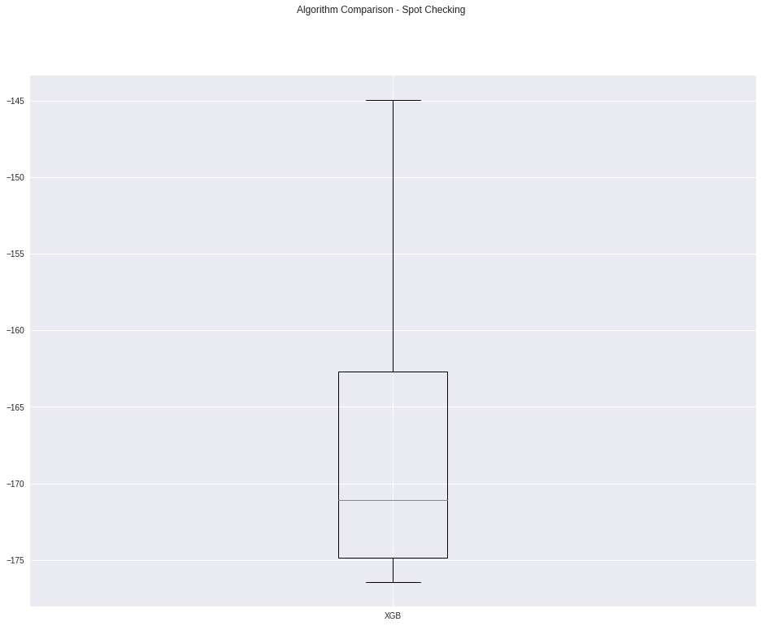

```python
fig = plt.figure(figsize=(16,12))
fig.suptitle('Algorithm Comparison - Spot Checking')
ax = fig.add_subplot(111)
plt.boxplot(train_results)
ax.set_xticklabels(train_model_names)
plt.show()
```

```python
if notifyStatus: status_notify("Task 4 - Train and Evaluate Models completed! "+datetime.now().strftime('%a %B %d, %Y %I:%M:%S %p'))
```

## Task 5 - Fine-tune and Improve Models

```python
if notifyStatus: status_notify("Task 5 - Fine-tune and Improve Models has begun! "+datetime.now().strftime('%a %B %d, %Y %I:%M:%S %p'))
```

### 5.a) Algorithm Tuning

```python
# Set up the comparison array
tune_results = []
tune_model_names = []
```

```python
# Tuning XGBoost n_estimators, max_depth, and min_child_weight parameters
startTimeModule = datetime.now()
if notifyStatus: status_notify("Algorithm tuning iteration #1 has begun! "+datetime.now().strftime('%a %B %d, %Y %I:%M:%S %p'))

tune_model1 = XGBRegressor(random_state=seedNum, n_jobs=n_jobs, objective='reg:squarederror', tree_method='gpu_hist')
tune_model_names.append('XGB_1')
paramGrid1 = dict(n_estimators=range(100,501,100), max_depth=np.array([6,9,12]), min_child_weight=np.array([2,3,4]))

kfold = KFold(n_splits=n_folds, shuffle=True, random_state=seedNum)
grid1 = GridSearchCV(estimator=tune_model1, param_grid=paramGrid1, scoring=scoring, cv=kfold, n_jobs=n_jobs, verbose=1)
grid_result1 = grid1.fit(X_train, y_train)

print("Best: %f using %s" % (grid_result1.best_score_, grid_result1.best_params_))
tune_results.append(grid_result1.cv_results_['mean_test_score'])
means = grid_result1.cv_results_['mean_test_score']
stds = grid_result1.cv_results_['std_test_score']
params = grid_result1.cv_results_['params']
for mean, stdev, param in zip(means, stds, params):
    print("%f (%f) with: %r" % (mean, stdev, param))
print ('Model training time:',(datetime.now() - startTimeModule))
if notifyStatus: status_notify("Algorithm tuning iteration #1 completed! "+datetime.now().strftime('%a %B %d, %Y %I:%M:%S %p'))
```

```
Fitting 5 folds for each of 45 candidates, totalling 225 fits
```

```
[Parallel(n_jobs=1)]: Using backend SequentialBackend with 1 concurrent workers.
[Parallel(n_jobs=1)]: Done 225 out of 225 | elapsed: 12.9min finished
```

```
Best: -100.897961 using {'max_depth': 9, 'min_child_weight': 3, 'n_estimators': 100}
-111.205022 (7.800449) with: {'max_depth': 6, 'min_child_weight': 2, 'n_estimators': 100}
-104.613516 (7.208561) with: {'max_depth': 6, 'min_child_weight': 2, 'n_estimators': 200}
-102.750516 (7.278813) with: {'max_depth': 6, 'min_child_weight': 2, 'n_estimators': 300}
-102.175506 (7.454751) with: {'max_depth': 6, 'min_child_weight': 2, 'n_estimators': 400}
-102.120583 (7.691355) with: {'max_depth': 6, 'min_child_weight': 2, 'n_estimators': 500}
-111.663467 (8.812694) with: {'max_depth': 6, 'min_child_weight': 3, 'n_estimators': 100}
-104.092368 (7.768160) with: {'max_depth': 6, 'min_child_weight': 3, 'n_estimators': 200}
-102.303279 (7.901993) with: {'max_depth': 6, 'min_child_weight': 3, 'n_estimators': 300}
-101.589705 (8.041215) with: {'max_depth': 6, 'min_child_weight': 3, 'n_estimators': 400}
-101.546460 (8.115231) with: {'max_depth': 6, 'min_child_weight': 3, 'n_estimators': 500}
-112.184567 (7.836619) with: {'max_depth': 6, 'min_child_weight': 4, 'n_estimators': 100}
-104.622692 (7.148017) with: {'max_depth': 6, 'min_child_weight': 4, 'n_estimators': 200}
-102.622086 (7.186201) with: {'max_depth': 6, 'min_child_weight': 4, 'n_estimators': 300}
-101.779900 (7.465246) with: {'max_depth': 6, 'min_child_weight': 4, 'n_estimators': 400}
-101.640616 (7.803754) with: {'max_depth': 6, 'min_child_weight': 4, 'n_estimators': 500}
-101.678888 (7.117040) with: {'max_depth': 9, 'min_child_weight': 2, 'n_estimators': 100}
-101.786919 (7.821578) with: {'max_depth': 9, 'min_child_weight': 2, 'n_estimators': 200}
-102.367196 (8.028153) with: {'max_depth': 9, 'min_child_weight': 2, 'n_estimators': 300}
-102.923868 (8.228161) with: {'max_depth': 9, 'min_child_weight': 2, 'n_estimators': 400}
-103.316838 (8.370663) with: {'max_depth': 9, 'min_child_weight': 2, 'n_estimators': 500}
-100.897961 (8.095964) with: {'max_depth': 9, 'min_child_weight': 3, 'n_estimators': 100}
-100.901431 (8.381342) with: {'max_depth': 9, 'min_child_weight': 3, 'n_estimators': 200}
-101.440356 (8.679782) with: {'max_depth': 9, 'min_child_weight': 3, 'n_estimators': 300}
-101.978508 (8.836833) with: {'max_depth': 9, 'min_child_weight': 3, 'n_estimators': 400}
-102.484765 (9.033117) with: {'max_depth': 9, 'min_child_weight': 3, 'n_estimators': 500}
-101.362241 (7.858014) with: {'max_depth': 9, 'min_child_weight': 4, 'n_estimators': 100}
-101.044757 (8.253986) with: {'max_depth': 9, 'min_child_weight': 4, 'n_estimators': 200}
-101.400314 (8.397751) with: {'max_depth': 9, 'min_child_weight': 4, 'n_estimators': 300}
-101.869527 (8.670701) with: {'max_depth': 9, 'min_child_weight': 4, 'n_estimators': 400}
-102.312201 (8.812983) with: {'max_depth': 9, 'min_child_weight': 4, 'n_estimators': 500}
-106.028139 (9.714152) with: {'max_depth': 12, 'min_child_weight': 2, 'n_estimators': 100}
-107.168995 (10.053421) with: {'max_depth': 12, 'min_child_weight': 2, 'n_estimators': 200}
-107.761573 (10.280071) with: {'max_depth': 12, 'min_child_weight': 2, 'n_estimators': 300}
-108.096032 (10.383082) with: {'max_depth': 12, 'min_child_weight': 2, 'n_estimators': 400}
-108.262539 (10.441076) with: {'max_depth': 12, 'min_child_weight': 2, 'n_estimators': 500}
-103.598308 (11.087194) with: {'max_depth': 12, 'min_child_weight': 3, 'n_estimators': 100}
-104.694446 (11.545732) with: {'max_depth': 12, 'min_child_weight': 3, 'n_estimators': 200}
-105.498308 (11.705129) with: {'max_depth': 12, 'min_child_weight': 3, 'n_estimators': 300}
-105.928196 (11.846913) with: {'max_depth': 12, 'min_child_weight': 3, 'n_estimators': 400}
-106.166025 (11.925715) with: {'max_depth': 12, 'min_child_weight': 3, 'n_estimators': 500}
-103.994810 (10.027427) with: {'max_depth': 12, 'min_child_weight': 4, 'n_estimators': 100}
-105.083251 (10.366630) with: {'max_depth': 12, 'min_child_weight': 4, 'n_estimators': 200}
-105.890856 (10.718345) with: {'max_depth': 12, 'min_child_weight': 4, 'n_estimators': 300}
-106.489800 (10.910167) with: {'max_depth': 12, 'min_child_weight': 4, 'n_estimators': 400}
-106.833769 (11.012603) with: {'max_depth': 12, 'min_child_weight': 4, 'n_estimators': 500}
Model training time: 0:12:54.825579
```

```python
# Tuning XGBoost subsample and colsample_bytree parameters
startTimeModule = datetime.now()
if notifyStatus: status_notify("Algorithm tuning iteration #2 has begun! "+datetime.now().strftime('%a %B %d, %Y %I:%M:%S %p'))

tune_model2 = XGBRegressor(n_estimators=100, max_depth=9, min_child_weight=3, random_state=seedNum, n_jobs=n_jobs, objective='reg:squarederror', tree_method='gpu_hist')
tune_model_names.append('XGB_2')
paramGrid2 = dict(subsample=np.array([0.7,0.8,0.9,1.0]), colsample_bytree=np.array([0.7,0.8,0.9,1.0]))

kfold = KFold(n_splits=n_folds, shuffle=True, random_state=seedNum)
grid2 = GridSearchCV(estimator=tune_model2, param_grid=paramGrid2, scoring=scoring, cv=kfold, n_jobs=n_jobs, verbose=1)
grid_result2 = grid2.fit(X_train, y_train)

print("Best: %f using %s" % (grid_result2.best_score_, grid_result2.best_params_))
tune_results.append(grid_result2.cv_results_['mean_test_score'])
means = grid_result2.cv_results_['mean_test_score']
stds = grid_result2.cv_results_['std_test_score']
params = grid_result2.cv_results_['params']
for mean, stdev, param in zip(means, stds, params):
    print("%f (%f) with: %r" % (mean, stdev, param))
print ('Model training time:',(datetime.now() - startTimeModule))
if notifyStatus: status_notify("Algorithm tuning iteration #2 completed! "+datetime.now().strftime('%a %B %d, %Y %I:%M:%S %p'))
```

```
Fitting 5 folds for each of 16 candidates, totalling 80 fits
```

```
[Parallel(n_jobs=1)]: Using backend SequentialBackend with 1 concurrent workers.
[Parallel(n_jobs=1)]: Done  80 out of  80 | elapsed:  1.7min finished
```

```
Best: -98.965397 using {'colsample_bytree': 0.8, 'subsample': 1.0}
-100.806255 (6.661417) with: {'colsample_bytree': 0.7, 'subsample': 0.7}
-99.966331 (7.539305) with: {'colsample_bytree': 0.7, 'subsample': 0.8}
-100.139178 (7.648704) with: {'colsample_bytree': 0.7, 'subsample': 0.9}
-99.979284 (7.538044) with: {'colsample_bytree': 0.7, 'subsample': 1.0}
-100.677702 (6.892477) with: {'colsample_bytree': 0.8, 'subsample': 0.7}
-99.680048 (7.870044) with: {'colsample_bytree': 0.8, 'subsample': 0.8}
-99.902283 (7.264591) with: {'colsample_bytree': 0.8, 'subsample': 0.9}
-98.965397 (8.790050) with: {'colsample_bytree': 0.8, 'subsample': 1.0}
-100.551396 (6.722965) with: {'colsample_bytree': 0.9, 'subsample': 0.7}
-99.291933 (6.571053) with: {'colsample_bytree': 0.9, 'subsample': 0.8}
-100.673322 (6.602219) with: {'colsample_bytree': 0.9, 'subsample': 0.9}
-99.956549 (8.265475) with: {'colsample_bytree': 0.9, 'subsample': 1.0}
-101.773158 (7.908904) with: {'colsample_bytree': 1.0, 'subsample': 0.7}
-100.922331 (7.352526) with: {'colsample_bytree': 1.0, 'subsample': 0.8}
-101.115370 (7.581579) with: {'colsample_bytree': 1.0, 'subsample': 0.9}
-100.897961 (8.095964) with: {'colsample_bytree': 1.0, 'subsample': 1.0}
Model training time: 0:01:40.556999
```

### 5.b) Compare Algorithms After Tuning

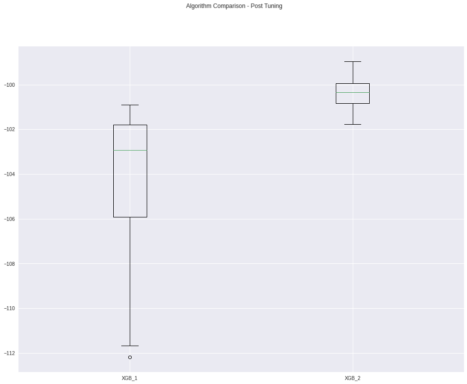

```python
fig = plt.figure(figsize=(16,12))
fig.suptitle('Algorithm Comparison - Post Tuning')
ax = fig.add_subplot(111)
plt.boxplot(tune_results)
ax.set_xticklabels(tune_model_names)
plt.show()
```

```python
if notifyStatus: status_notify("Task 5 - Fine-tune and Improve Models completed! "+datetime.now().strftime('%a %B %d, %Y %I:%M:%S %p'))
```

## Task 6 - Finalize Model and Present Analysis

```python
if notifyStatus: status_notify("Task 6 - Finalize Model and Present Analysis has begun! "+datetime.now().strftime('%a %B %d, %Y %I:%M:%S %p'))
```

### 6.a) Validate the models using the validation dataset

```python
validation_model = XGBRegressor(n_estimators=100, max_depth=9, min_child_weight=3, colsample_bytree=0.8, subsample=1.0, random_state=seedNum, n_jobs=n_jobs, objective='reg:squarederror', tree_method='gpu_hist')
validation_model.fit(X_train, y_train)
print(validation_model)
val_predictions = validation_model.predict(X_validation)
print('RMSE for the model is: ', math.sqrt(mean_squared_error(y_validation, val_predictions)))
print('R2 for the model is: ', r2_score(y_validation, val_predictions))
```

```
XGBRegressor(base_score=0.5, booster='gbtree', colsample_bylevel=1,
             colsample_bynode=1, colsample_bytree=0.8, gamma=0,
             importance_type='gain', learning_rate=0.1, max_delta_step=0,
             max_depth=9, min_child_weight=3, missing=None, n_estimators=100,
             n_jobs=1, nthread=None, objective='reg:squarederror',
             random_state=888, reg_alpha=0, reg_lambda=1, scale_pos_weight=1,
             seed=None, silent=None, subsample=1.0, tree_method='gpu_hist',
             verbosity=1)
RMSE for the model is:  9.884217254890743
R2 for the model is:  0.9124794035913133
```

### 6.b) Create a test model using all available data

```python
# Combining the training and validation datasets to form the complete dataset that will be used for training the final model
X_complete = np.vstack((X_train, X_validation))
y_complete = np.concatenate((y_train, y_validation))
print("X_complete.shape: {} y_complete.shape: {}".format(X_complete.shape, y_complete.shape))
test_model = validation_model.fit(X_complete, y_complete)
print(test_model)
```

```
X_complete.shape: (17010, 80) y_complete.shape: (17010,)
XGBRegressor(base_score=0.5, booster='gbtree', colsample_bylevel=1,
             colsample_bynode=1, colsample_bytree=0.8, gamma=0,
             importance_type='gain', learning_rate=0.1, max_delta_step=0,
             max_depth=9, min_child_weight=3, missing=None, n_estimators=100,
             n_jobs=1, nthread=None, objective='reg:squarederror',
             random_state=888, reg_alpha=0, reg_lambda=1, scale_pos_weight=1,
             seed=None, silent=None, subsample=1.0, tree_method='gpu_hist',
             verbosity=1)
```

### 6.c) Load test dataset and measure predictions

```python
# Apply feature scaling and transformation to the test dataset
scaled_features = scaler.transform(X_test_df[columns_to_scale])
X_test_df.loc[:,tuple(columns_to_scale)] = scaled_features
print(X_test_df.head())
```

```
       mean_atomic_mass  wtd_mean_atomic_mass  ...  std_Valence  wtd_std_Valence
11253          0.054721              0.039394  ...     0.166667         0.152753
18632          0.257159              0.245443  ...     0.157135         0.166667
3538           0.399901              0.227525  ...     0.210819         0.090804
528            0.344372              0.248747  ...     0.144338         0.146984
2985           0.384926              0.357513  ...     0.124226         0.116642

[5 rows x 80 columns]
```

```python
# Finalize the test dataset for the modeling testing
X_test = X_test_df.to_numpy()
y_test = y_test_df.ravel()
print("X_test.shape: {} y_test.shape: {}".format(X_test.shape, y_test.shape))
```

```
X_test.shape: (4253, 80) y_test.shape: (4253,)
```

```python
test_predictions = test_model.predict(X_test)
print('RMSE for the model is: ', math.sqrt(mean_squared_error(y_test, test_predictions)))
print('R2 for the model is: ', r2_score(y_test, test_predictions))
```

```
RMSE for the model is:  9.068999424304168
R2 for the model is:  0.9293363219555656
```

```python
if notifyStatus: status_notify("Task 6 - Finalize Model and Present Analysis completed! "+datetime.now().strftime('%a %B %d, %Y %I:%M:%S %p'))
```

```python
print ('Total time for the script:',(datetime.now() - startTimeScript))
```

```
Total time for the script: 0:15:22.376136
```